# 07 - Mock Analysis

Biostatistics 735 — Machine Learning in Public Health

Author

Alexander McLain

Published

September 10, 2026

```r
set.seed(735794)
library(tidyverse)
library(janitor)
library(rsample)   # group_vfold_cv(), rolling_origin()
library(mgcv)      # gam()
library(genlasso)  # fusedlasso1d()
library(glmnet)
library(grpreg)     # group lasso
library(nhanesA)    # NHANES data pull
library(BGLR)       # wheat data
library(kableExtra)

select <- dplyr::select
```

# 1 Scenario 1: NHANES

**Goal:** Predict systolic blood pressure from demographic and body-measurement variables using a recent NHANES cycle.

**Intended CV issue:** NHANES uses a complex, clustered survey design. Participants are sampled within primary sampling units (`SDMVPSU`), nested within strata (`SDMVSTRA`). Observations within the same PSU are more similar to each other than to observations in a different PSU (shared geography, recruitment site, local population characteristics). A random row-level CV split puts people from the same PSU in both training and validation folds, which overstates performance — the same leakage mechanism as splitting repeated visits on the same subject, just from geographic clustering instead of time.

**Intended method:** GAM, since age and BMI effects on blood pressure are plausibly nonlinear (we just covered `s()` terms) and NHANES is large enough to estimate smooth terms comfortably.

## 1.1 Pulling the Data

```r
demo <- nhanes("DEMO_J")   # 2017-2018 cycle: demographics, SDMVPSU, SDMVSTRA
bpx  <- nhanes("BPX_J")    # blood pressure exam
bmx  <- nhanes("BMX_J")    # body measures

str(demo[, c("SEQN", "RIDAGEYR", "RIAGENDR", "SDMVPSU", "SDMVSTRA")])
```

```
'data.frame':   9254 obs. of  5 variables:
 $ SEQN    : num  93703 93704 93705 93706 93707 ...
 $ RIDAGEYR: num  2 2 66 18 13 66 75 0 56 18 ...
 $ RIAGENDR: Factor w/ 2 levels "Male","Female": 2 1 2 1 1 2 2 2 1 1 ...
 $ SDMVPSU : num  2 1 2 2 1 2 1 1 2 2 ...
 $ SDMVSTRA: num  145 143 145 134 138 138 136 134 134 147 ...
```

```r
# SDMVPSU only takes values 1–2 and is nested within each stratum,
# not a standalone cluster ID. To get a cluster ID we need to combine
# psu and strata.
nhanes_df <- demo |>
  select(SEQN, age = RIDAGEYR, sex = RIAGENDR, race.eth = RIDRETH3,
         educ = DMDEDUC2, married = DMDHRMAZ,
         psu = SDMVPSU, strata = SDMVSTRA) |>
  left_join(bpx |> select(SEQN, sysBP = BPXSY1), by = "SEQN") |>
  left_join(bmx |> select(SEQN, BMI = BMXBMI), by = "SEQN")  |>
  mutate(cluster = interaction(strata, psu, drop = TRUE)) |>
  drop_na()

nrow(nhanes_df)
```

```
[1] 4550
```

```r
n_distinct(nhanes_df$cluster)   # should be 30 (15 strata x 2 psu)
```

```
[1] 30
```

```r
table(nhanes_df$cluster)
```

```
134.1 135.1 136.1 137.1 138.1 139.1 140.1 141.1 142.1 143.1 144.1 145.1 146.1
  106   144   156   158   157   140   173   151   180   106   205   171   122
147.1 148.1 134.2 135.2 136.2 137.2 138.2 139.2 140.2 141.2 142.2 143.2 144.2
  159   142   147   173   181   130   135   167   146   167   177   146   149
145.2 146.2 147.2 148.2
  132   160   119   151
```

## 1.2 The Wrong Way: Naive Row-Level CV

```r
set.seed(1)
folds_naive <- vfold_cv(nhanes_df, v = 5)

rmse_naive <- map_dbl(folds_naive$splits, function(s) {
  tr <- analysis(s); va <- assessment(s)
  fit <- gam(sysBP ~ s(age, by = sex) + s(BMI, by = sex) + sex +
               race.eth + educ + married, data = tr, method = "REML")
  sqrt(mean((va$sysBP - predict(fit, newdata = va))^2))
})

mean(rmse_naive)
```

```
[1] 16.55477
```

## 1.3 The Right Way: Grouping by Cluster

```r
set.seed(1)
folds_psu <- group_vfold_cv(nhanes_df, group = cluster, v = 5)

rmse_grouped <- map_dbl(folds_psu$splits, function(s) {
  tr <- analysis(s); va <- assessment(s)
  fit <- gam(sysBP ~ s(age, by = sex) + s(BMI, by = sex) + sex +
               race.eth + educ + married, data = tr, method = "REML")
  sqrt(mean((va$sysBP - predict(fit, newdata = va))^2))
})

mean(rmse_grouped)
```

```
[1] 16.55789
```

```r
tibble(
  CV_design = c("Naive (row-level)", "Grouped by Cluster"),
  Mean_RMSE = c(mean(rmse_naive), mean(rmse_grouped))
)
```

```
# A tibble: 2 × 2
  CV_design          Mean_RMSE
  <chr>                  <dbl>
1 Naive (row-level)       16.6
2 Grouped by Cluster      16.6
```

**Debrief point:** if the naive CV RMSE is meaningfully lower than the grouped CV RMSE, that gap *is* the leakage — it’s an estimate of how much the model was “cheating” by seeing correlated observations from the same PSU on both sides of the split.

## 1.4 A New Question: Does Error Vary by Race/Ethnicity

```r
set.seed(1)
grouped_preds <- map_dfr(folds_psu$splits, function(s) {
  tr <- analysis(s); va <- assessment(s)
  fit <- gam(sysBP ~ s(age, by = sex) + s(BMI, by = sex) + sex +
               race.eth + educ + married, data = tr, method = "REML")

  va |>
    mutate(pred = predict(fit, newdata = va)) |>
    select(race.eth, sysBP, pred)
})

rmse_by_race_grouped <- grouped_preds |>
  mutate(sq_err = (sysBP - pred)^2) |>
  group_by(race.eth) |>
  summarize(
    n       = n(),
    avg_obs = mean(sysBP),
    avg_pred = mean(pred),
    mse     = mean(sq_err),
    se_mse  = sd(sq_err) / sqrt(n),
    rmse    = sqrt(mse),
    se_rmse = se_mse / (2 * rmse),        # delta method: SE(sqrt(x)) ~= SE(x) / (2*sqrt(x))
    ci_lower = rmse - 1.96 * se_rmse,
    ci_upper = rmse + 1.96 * se_rmse,
    .groups = "drop"
  ) |>
  arrange(desc(rmse))

rmse_by_race_grouped |>
  transmute(
    `Race/Ethnicity` = race.eth,
    `n`              = n,
    `Avg Obs` = round(avg_obs,1),
    `Avg Pred` = round(avg_pred,1),
    `Avg Diff` = round(avg_obs - avg_pred,2),
    `RMSE`           = round(rmse, 2),
    `SE`             = round(se_rmse, 3),
    `95% CI`         = paste0("(", round(ci_lower, 2), ", ", round(ci_upper, 2), ")")
  ) |>
  kable(align = "lrrrr", caption = "RMSE by Race/Ethnicity with Approximate 95% CIs")
```

RMSE by Race/Ethnicity with Approximate 95% CIs

| Race/Ethnicity | n | Avg Obs | Avg Pred | Avg Diff | RMSE | SE | 95% CI |
| --- | --- | --- | --- | --- | --- | --- | --- |
| Non-Hispanic Black | 1056 | 130.8 | 130.9 | -0.05 | 18.30 | 0.535 | (17.26, 19.35) |
| Other Hispanic | 413 | 125.7 | 125.8 | -0.09 | 17.86 | 0.805 | (16.28, 19.44) |
| Other Race - Including Multi-Racial | 225 | 126.4 | 126.4 | -0.05 | 16.91 | 1.030 | (14.89, 18.93) |
| Non-Hispanic Asian | 658 | 124.4 | 124.3 | 0.14 | 15.99 | 0.690 | (14.64, 17.34) |
| Non-Hispanic White | 1595 | 125.7 | 125.8 | -0.08 | 15.74 | 0.337 | (15.08, 16.4) |
| Mexican American | 603 | 124.8 | 124.7 | 0.12 | 15.04 | 0.808 | (13.46, 16.62) |

# 2 Scenario 2: Testing Volume and Percent Positive

**Goal:** Using weekly test-volume and percent-positive data from the five most populous states, predict (a) total weekly specimens tested and (b) percent positive, for future weeks.

**CV issue:** Two, layered. First, temporal ordering — the outcome in week $t$ is correlated with weeks $t-1, t-2, \dots$, so a random split lets the model see the future. CV has to be a rolling-origin / forward-chaining design. Second, if state is entered as a fixed effect, the fitted model cannot generalize to a state it never saw in training — worth surfacing even though we aren’t holding out a state here, because it constrains what this model can and can’t be used for later.

**Intended methods:** GAM and fused lasso (captures the piecewise trend / regime shifts in each state’s series — a direct callback to the fused-lasso lesson). For `state` we can use a fixed-effects linear model since there are only 5 states.

## 2.1 Data Setup

```r
flu_raw <- read_csv("ICL_NREVSS_Clinical_Labs.csv", skip = 1, na = "X") |>
  clean_names()

top5_states <- c("California", "Texas", "Florida", "New York", "Pennsylvania")

flu_df <- flu_raw |>
  rename(state = region,
         total_tests  = total_specimens,
         pct_positive = percent_positive) |>
  filter(state %in% top5_states) |>
  arrange(state, year, week) |>          # chronological order WITHIN each state
  select(state, year, week, total_tests, pct_positive) |>
  group_by(state) |>
  mutate(t = row_number()) |>            # sequential time index that respects year + week
  ungroup()

flu_df |> count(state)
```

```
# A tibble: 5 × 2
  state            n
  <chr>        <int>
1 California     569
2 Florida        569
3 New York       569
4 Pennsylvania   569
5 Texas          569
```

**Note**

If I was modeling this data, I would log-transform the pct_positive variable. Here, for clean interpretations, we won’t do this.

**Important**

`week` alone resets every season (1–52/53), so ordering by `week` without `year` first silently interleaves different flu seasons — week 40 of 2015 would sort next to week 40 of 2019. `arrange(state, year, week)` fixes the chronology; `t` is then a clean sequential index per state that both the rolling-origin split and the fused lasso can rely on.

## 2.2 Why the Two “Obvious” Approaches Don’t Actually Answer the Question

The handout goal is genuine forecasting — total specimens and percent positive for a **future** week/year, e.g., California, 2026, week 50. That requirement rules out a couple of approaches:

- **Fused lasso on the raw time series** estimates one coefficient per *observed* time point. There is no coefficient for “week 50 of 2026” because that row doesn’t exist in the fitted path — the model has nothing to extrapolate with. It’s a good *descriptive* tool for finding past regime shifts, but not a predictive one for a genuinely new time point.
- **`week_num` as a sequential index fed into a fixed-effects model** has the same problem in a different place: it’s tied to the training data’s specific rows, not a reusable calendar concept. There’s no principled way to hand the model “week_num = (whatever a 2026 week-50 row would have been).”

What actually generalizes to a new year/week is a model with **separate, interpretable terms for week and year**: a cyclic seasonal effect for week (defined for all 52 weeks, so no extrapolation needed there at all) and a linear trend for year (which *can* be extrapolated, honestly, a few years out). `state` re-enters as a plain fixed effect — a factor term.

## 2.3 Model: GAM with Cyclic Week Smooth + Linear Year + State Fixed Effect

```r
gam_fit <- gam(
  pct_positive ~ state + s(week, bs = "cc", k = 10) + year,
  data   = flu_df,
  knots  = list(week = c(0.5, 52.5)),   # ties week 52 back to week 1
  method = "REML"
)

summary(gam_fit)
```

```
Family: gaussian
Link function: identity

Formula:
pct_positive ~ state + s(week, bs = "cc", k = 10) + year

Parametric coefficients:
                   Estimate Std. Error t value Pr(>|t|)
(Intercept)       512.62128   75.94977   6.749 1.79e-11 ***
stateFlorida        1.79589    0.37325   4.811 1.58e-06 ***
stateNew York       0.08895    0.37325   0.238    0.812
statePennsylvania   0.38954    0.37342   1.043    0.297
stateTexas          1.85209    0.37325   4.962 7.39e-07 ***
year               -0.25101    0.03759  -6.678 2.90e-11 ***
---
Signif. codes:  0 '***' 0.001 '**' 0.01 '*' 0.05 '.' 0.1 ' ' 1

Approximate significance of smooth terms:
          edf Ref.df     F p-value
s(week) 7.214      8 246.5  <2e-16 ***
---
Signif. codes:  0 '***' 0.001 '**' 0.01 '*' 0.05 '.' 0.1 ' ' 1

R-sq.(adj) =  0.419   Deviance explained = 42.2%
-REML = 9283.8  Scale est. = 39.636    n = 2844
```

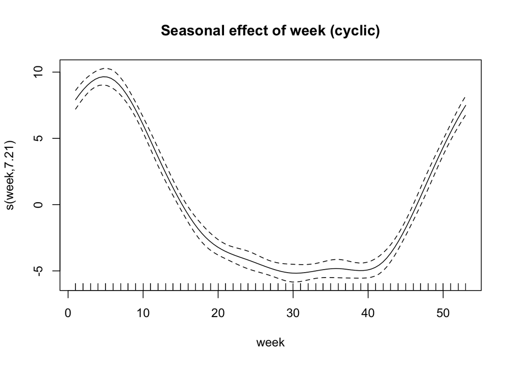

```r
plot(gam_fit, select = 1, shade = TRUE, main = "Seasonal effect of week (cyclic)")
```

`s(week, bs = "cc")` is a **cyclic** cubic smooth — it forces the fitted curve at week 52 to connect back to week 1, the right assumption for a seasonal effect (there’s no real discontinuity between the last week of one flu season and the first week of the next). `year` enters linearly, so it contributes a single extrapolable slope rather than a value tied to specific observed years. `state` is a plain factor term — a fixed effect exactly as requested, fit directly in `gam()`.

**Note**

`refund::pfr()` would fit this identical model — it’s built directly on top of `mgcv::gam()` and accepts the same formula syntax when there’s no functional predictor involved. `gam()` is used here because nothing in this formula is actually functional (unlike the DTI example); `pfr()` becomes necessary once you have a genuine curve as a predictor, not before.

## 2.4 Honest Error Estimation: Rolling-Origin CV, Actually Used

```r
flu_df <- flu_df |>
  mutate(calendar_t = (year - min(year)) * 52 + week) |>
  arrange(calendar_t, state)

weeks_sorted  <- sort(unique(flu_df$calendar_t))
initial_weeks <- 104   # ~2 seasons before the first forecast
horizon_weeks <- 4     # forecast 4 weeks ahead at each cutoff

cutoffs <- weeks_sorted[initial_weeks:(length(weeks_sorted) - horizon_weeks)]
cutoffs[1:5]
```

```
[1] 143 144 145 146 147
```

```r
cv_results <- map_dfr(cutoffs, function(cut) {
  train <- flu_df |> filter(calendar_t <= cut)
  test  <- flu_df |> filter(calendar_t > cut, calendar_t <= cut + horizon_weeks)
  if (nrow(test) == 0) return(NULL)

  fit <- gam(pct_positive ~ state + s(week, bs = "cc", k = 10) + year,
             data = train, knots = list(week = c(0.5, 52.5)), method = "REML")

  tibble(
    cutoff = cut,
    rmse   = sqrt(mean((test$pct_positive - predict(fit, newdata = test))^2, na.rm = TRUE))
  )
})

head(cv_results)
```

```
# A tibble: 6 × 2
  cutoff  rmse
   <dbl> <dbl>
1    143  1.40
2    144  1.85
3    145  2.52
4    146  3.21
5    147  4.42
6    148  5.02
```

```r
mean(cv_results$rmse)
```

```
[1] 5.503506
```

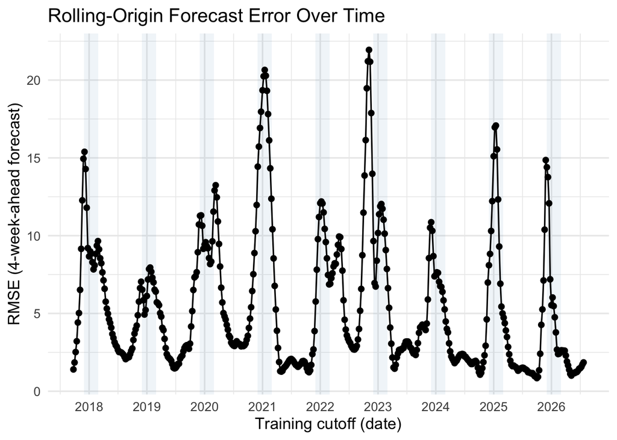

```r
min_year <- min(flu_df$year)

cv_results <- cv_results |>
  mutate(
    approx_year = min_year + (cutoff - 1) %/% 52,
    approx_week = (cutoff - 1) %% 52 + 1,
    # Approximate date for the start of that MMWR week (good enough for plotting)
    approx_date = as.Date(paste0(approx_year, "-01-01")) + (approx_week - 1) * 7
  )

ggplot(cv_results, aes(approx_date, rmse)) +
  # Shade Dec-Feb each year so winter/flu-season is visible at a glance
  annotate("rect",
           xmin = as.Date(paste0(min_year:(min_year + 10), "-12-01"))[-c(1,2)],
           xmax = as.Date(paste0((min_year + 1):(min_year + 11), "-03-01"))[-c(1,2)],
           ymin = -Inf, ymax = Inf, fill = "steelblue", alpha = 0.08) +
  geom_line() +
  geom_point() +
  scale_x_date(date_breaks = "1 year", date_labels = "%Y") +
  labs(title = "Rolling-Origin Forecast Error Over Time",
       x = "Training cutoff (date)", y = "RMSE (4-week-ahead forecast)") +
  theme_minimal(base_size = 13)
```

This refits `gam()` at every cutoff using only data available up to that point, then evaluates on the following month — exactly how the model would be used in practice. `mean(cv_results$rmse)` is the number to report as the model’s expected forecast error, not any single train/test split.

**Important**

This loop refits the model dozens of times, which is the honest cost of doing CV properly for a forecasting model. Resist the temptation to shortcut it with a single holdout at the end — one split gives a noisy point estimate, not a distribution you can trust.

## 2.5 Forecasting a Genuinely Future Observation

```r
final_fit <- gam(pct_positive ~ state + s(week, bs = "cc", k = 10) + year,
                  data = flu_df, knots = list(week = c(0.5, 52.5)), method = "REML")

future_point <- tibble(state = "California", year = 2026, week = 50)
predict(final_fit, newdata = future_point, se.fit = TRUE)
```

```
$fit
       1
8.408783

$se.fit
        1
0.4561324
```

**Important**

This prediction is only as trustworthy as the linear extrapolation in `year`. The seasonal `week` effect is well-supported (fit on the full observed cycle), but the `year` coefficient is extrapolating past the last observed year and cannot know about a genuine future disruption (a new variant, another pandemic-scale event). Report the rolling-origin CV RMSE alongside any such forecast as the honest uncertainty, and treat a multi-year-out extrapolation as considerably shakier than a same-season forecast.

The same approach — cyclic week smooth, linear year, state fixed effect, rolling-origin CV — applies to `total_tests`: refit with `total_tests ~ state + s(week, bs = "cc", k = 10) + year` and repeat the CV loop above.

**Important**

**The limitation to flag explicitly.** A fixed effect for `state` is estimated *only* for the states in the training data. There is no mechanism in this model for predicting a sixth state that wasn’t part of the fit — the model has literally no parameter for it. If the eventual goal is a model that generalizes to new states (not just the five here), a fixed-effects approach is the wrong tool; you’d want something that treats state as a random effect or borrows strength across states (e.g., a hierarchical model), which is beyond what we’ve covered so far. Worth having the group articulate this limitation even though it doesn’t change what they fit today.

### 2.5.1 Repeating for log-transformed outcome

Below, I’m repeating the entire thing for a log transformed outcome:

```r
flu_df <- flu_df |>
  mutate(l_pct_positive = log(if_else(pct_positive==0, 1/total_tests*100, pct_positive))) |>
  arrange(calendar_t, state)

weeks_sorted  <- sort(unique(flu_df$calendar_t))
initial_weeks <- 104   # ~2 seasons before the first forecast
horizon_weeks <- 4     # forecast 4 weeks ahead at each cutoff

cutoffs <- weeks_sorted[initial_weeks:(length(weeks_sorted) - horizon_weeks)]

cv_results <- map_dfr(cutoffs, function(cut) {
  train <- flu_df |> filter(calendar_t <= cut)
  test  <- flu_df |> filter(calendar_t > cut, calendar_t <= cut + horizon_weeks)
  if (nrow(test) == 0) return(NULL)

  fit <- gam(l_pct_positive ~ state + s(week, bs = "cc", k = 10) + year,
             data = train, knots = list(week = c(0.5, 52.5)), method = "REML")

  tibble(
    cutoff = cut,
    rmse   = sqrt(mean((test$pct_positive - predict(fit, newdata = test))^2, na.rm = TRUE))
  )
})

mean(cv_results$rmse)
```

```
[1] 6.454972
```

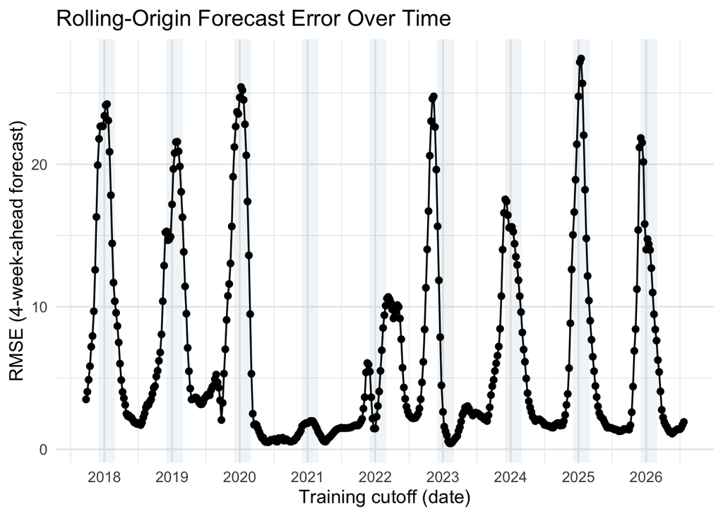

```r
min_year <- min(flu_df$year)

cv_results <- cv_results |>
  mutate(
    approx_year = min_year + (cutoff - 1) %/% 52,
    approx_week = (cutoff - 1) %% 52 + 1,
    # Approximate date for the start of that MMWR week (good enough for plotting)
    approx_date = as.Date(paste0(approx_year, "-01-01")) + (approx_week - 1) * 7
  )

ggplot(cv_results, aes(approx_date, rmse)) +
  # Shade Dec-Feb each year so winter/flu-season is visible at a glance
  annotate("rect",
           xmin = as.Date(paste0(min_year:(min_year + 10), "-12-01"))[-c(1,2)],
           xmax = as.Date(paste0((min_year + 1):(min_year + 11), "-03-01"))[-c(1,2)],
           ymin = -Inf, ymax = Inf, fill = "steelblue", alpha = 0.08) +
  geom_line() +
  geom_point() +
  scale_x_date(date_breaks = "1 year", date_labels = "%Y") +
  labs(title = "Rolling-Origin Forecast Error Over Time",
       x = "Training cutoff (date)", y = "RMSE (4-week-ahead forecast)") +
  theme_minimal(base_size = 13)
```

```r
final_fit <- gam(l_pct_positive ~ state + s(week, bs = "cc", k = 10) + year,
                  data = flu_df, knots = list(week = c(0.5, 52.5)), method = "REML")

future_point <- tibble(state = "California", year = 2026, week = 50)
pred_vals <- predict(final_fit, newdata = future_point, se.fit = TRUE)

tibble(pred = exp(pred_vals$fit), se.fit = pred_vals$se.fit*exp(pred_vals$fit))
```

```
# A tibble: 1 × 2
       pred    se.fit
  <dbl[1d]> <dbl[1d]>
1      4.00     0.379
```

## 2.6 Fused Lasso

For fun, I wanted to fit this model with the fused LASSO. What’s cool about this is that I can fuse the coefficients in two directions `year` and `week`. Let’s check it out:

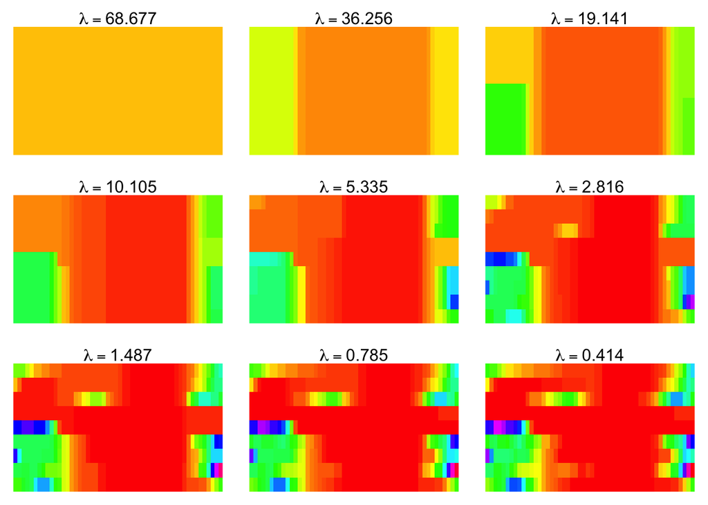

```r
# ============================================================
# Step 1: Fit the 2D fused lasso on years up to 2024 (holding out 2025)
# ============================================================
fused_train <- flu_df |>
  filter(state == "California") |>
  filter(year > 2015 & year < 2025 & week < 53) |>   # complete years, 2025 excluded
  arrange(year, week)                                 # week must vary fastest within each year

dim1 <- length(unique(fused_train$week))   # 52 weeks
dim2 <- length(unique(fused_train$year))   # years 2016-2024

fl_train <- fusedlasso2d(fused_train$pct_positive, dim1 = dim1, dim2 = dim2)

# Grab a fine path of lambdas so the validation curve below isn't lumpy
a_train <- coef(fl_train, nlam = 30)

# ============================================================
# Keep the 3x3 plot of coefficients from the TRAINING-ONLY fit
# (same 9-lambda snapshot as before, just refit without 2025)
# ============================================================
a9 <- coef(fl_train, nlam = 9)

par(mar = c(1, 1, 2, 1), mfrow = c(3, 3))
cols <- rainbow(100)
zlim <- range(a9$beta)
for (i in 1:9) {
  image(matrix(a9$beta[, i], nrow = dim1), col = cols, zlim = zlim, axes = FALSE)
  mtext(bquote(lambda == .(sprintf("%.3f", a9$lambda[i]))))
}
```

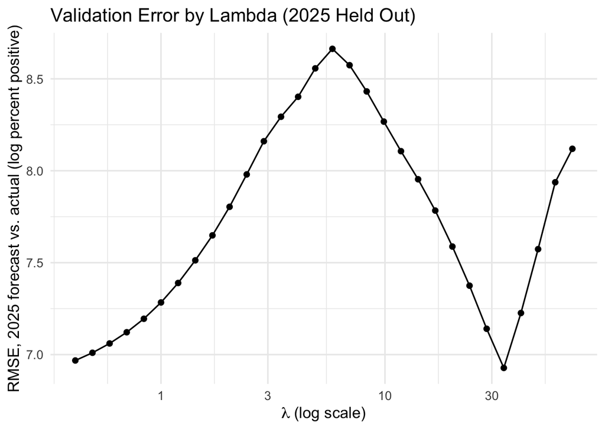

```r
# ============================================================
# Step 2: Predict 2025 from the training fit, at every lambda,
# and see which lambda gives the lowest holdout error
# ============================================================

# The fused lasso has no coefficient beyond the training grid, so the natural
# forecast for a year it never saw is the LAST fitted year's curve
# (total-variation regularization assumes adjacent cells are similar --
# "next year looks like last year" is the model's own implied forecast).

weeks_grid <- sort(unique(fused_train$week))

holdout_2025 <- flu_df |>
  filter(state == "California", year == 2025, week < 53) |>
  arrange(week)

forecast_rmse <- map_dbl(seq_along(a_train$lambda), function(j) {
  beta_mat <- matrix(a_train$beta[, j], nrow = dim1, ncol = dim2)
  last_year_col <- beta_mat[, dim2]                # fitted 2024 curve
  names(last_year_col) <- weeks_grid

  pred_2025 <- last_year_col[as.character(holdout_2025$week)]
  sqrt(mean((holdout_2025$pct_positive - pred_2025)^2, na.rm = TRUE))
})

lambda_err <- tibble(lambda = a_train$lambda, rmse = forecast_rmse)

ggplot(lambda_err, aes(lambda, rmse)) +
  geom_line() + geom_point() +
  scale_x_log10() +
  labs(title = "Validation Error by Lambda (2025 Held Out)",
       x = expression(lambda ~ "(log scale)"),
       y = "RMSE, 2025 forecast vs. actual (log percent positive)") +
  theme_minimal(base_size = 13)
```

```r
lambda_best <- lambda_err$lambda[which.min(lambda_err$rmse)]
lambda_best
```

```
[1] 33.93791
```

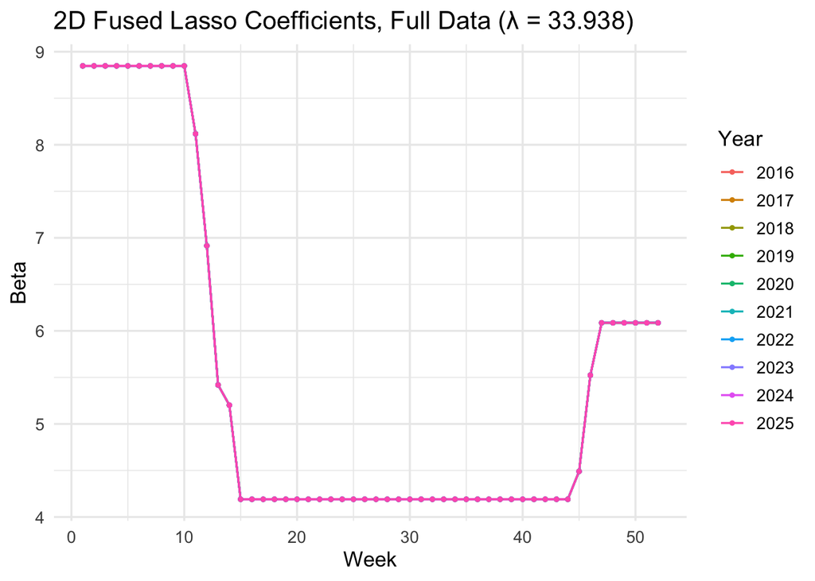

```r
# ============================================================
# Step 3: Refit at lambda_best using ALL data (now including 2025),
# display the coefficients with ggplot
# ============================================================
fused_full <- flu_df |>
  filter(state == "California") |>
  filter(year > 2015 & year < 2026 & week < 53) |>
  arrange(year, week)

dim1_full <- length(unique(fused_full$week))
dim2_full <- length(unique(fused_full$year))

fl_full <- fusedlasso2d(fused_full$pct_positive, dim1 = dim1_full, dim2 = dim2_full)

beta_full <- coef(fl_full, lambda = lambda_best)$beta

plot_full <- fused_full |>
  mutate(Beta = as.vector(beta_full),
         year_f = factor(year))

ggplot(plot_full, aes(week, Beta, color = year_f)) +
  geom_line() + geom_point(size = 0.8) +
  labs(title = paste0("2D Fused Lasso Coefficients, Full Data (\u03bb = ",
                       round(lambda_best, 3), ")"),
       x = "Week", y = "Beta", color = "Year") +
  theme_minimal(base_size = 13)
```

```r
# ============================================================
# Step 4: Predict 2025 week 50 from the full refit, then carry that
# forward as the prediction for 2026 week 50
# ============================================================
weeks_grid_full <- sort(unique(fused_full$week))
years_grid_full  <- sort(unique(fused_full$year))

beta_mat_full <- matrix(beta_full, nrow = dim1_full, ncol = dim2_full,
                         dimnames = list(weeks_grid_full, years_grid_full))

pred_2025_wk50 <- beta_mat_full[as.character(50), as.character(2025)]
pred_2026_wk50 <- pred_2025_wk50   # no coefficient exists beyond the observed grid

tibble(
  year = c(2025, 2026),
  week = 50,
  predicted_pct_positive = c(pred_2025_wk50, pred_2026_wk50))
```

```
# A tibble: 2 × 3
   year  week predicted_pct_positive
  <dbl> <dbl>                  <dbl>
1  2025    50                   6.09
2  2026    50                   6.09
```

**Important**

Notice the 2026 prediction is identical to the 2025 one — the fused lasso literally has no parameter for a cell outside the fitted grid, so “predicting 2026” here just means assuming next year looks like the last observed year. That’s a fine baseline, but it’s a much weaker extrapolation than the year-as-linear-term GAM from earlier in this document, which can actually project a trend forward. Worth having students compare the two 2026 forecasts side by side.